# Vancouver Crime Prediction Report

Ramiro Francisco Mejia, Jasmine Ortega, Thomas Siu, Shi Yan Wang  
2021-12-09

## Introduction

Crime is a daily occurrence in large cities, and Vancouver is no exception to this rule. While crime is impossible to avoid in a large metropolitan city, we are interested in seeing if the categories of crimes and timing of crime can be correlated with certain neighborhoods in Vancouver. The information is useful for the police to strengthen specific skillsets to cater specific law-breaching activities in different areas. Also, local government officials can utilize the prediction to adjust related policies. This project is for educational purposes only and should not be used to predict crime in real life.

## Methods

The Python programming language (Van Rossum and Drake Jr 1995) and the following Python packages are used to perform the analysis: Pandas (McKinney et al. 2010), Numpy (Harris et al. 2020), Sci-Kit Learn (Pedregosa et al. 2011), Altair (VanderPlas et al. 2018), dataframe_image (Petrou 2018) and docopt (de Jonge 2018).

The code used to perform the analysis and create this report can be found here: https://github.com/UBC-MDS/DSCI_522_Crime_Prediction_Vancouver/blob/main/src/modelling.ipynb

## Data

The data was collected by the Vancouver Police Department (The Vancouver Police Department 2021) from 2003 to 2021 and is a log of all crimes committed. Each row in the dataset represents the crime committed, the time of day, neighborhood, the hundreds block the crime occurred on, as well as the X and Y coordinates of the crime location. It is updated weekly by the VPD, but there is about a two to three month lag in logging present day crime. To simplify our analysis and prediction modelling, we utilized the data between year 2016 to 2020.

## Analysis

### EDA

In our initial exploratory data analysis, the relationship between neighborhoods and types of crime was examined. From the heatmap below, the Central Business District (compromising of the downtown area) appears to be the most active neighborhood for crime against all neighborhoods.

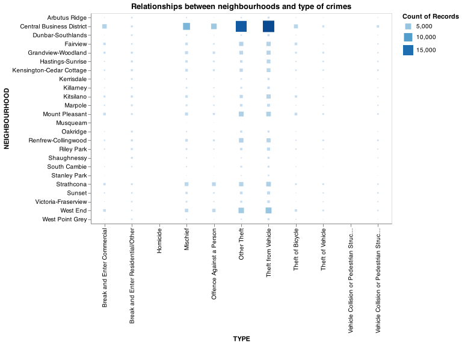

Figure 1. Heatmap of Crimes and Neighborhood

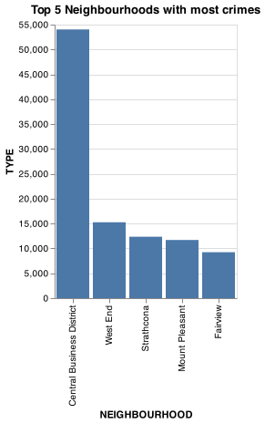

Figure 2: Top 5 Neighborhoods with Crime

### Data cleaning

Additionally, we examined the distribution of crimes committed against hours. A significant amount of cases happened in hour 0. However, this appeared to be an issue within the dataset. It appeared many crimes logged at 0 AM as a default in cases where the original time of the crime is unknown or not available. Also, based on the data description provided by the VPD, the hour information was based on the findings of the police investigation. See here for the data specification. Thus we assumed some examples falling into hour 0 could have happened in other time in the same day. To counteract this imabalance, data re-balancing was done by averaging out the cases from 0 am and re-distributing into 24 hours.

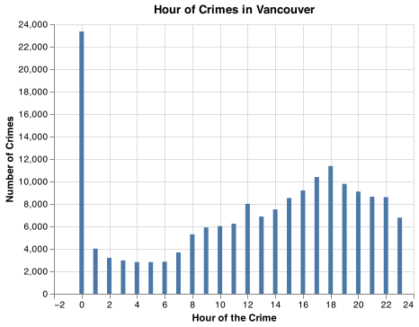

Figure 3. Data Before Rebalancing

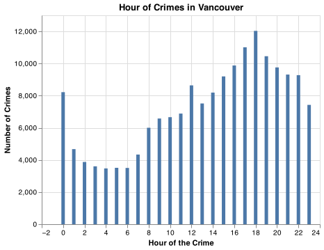

Figure 4. The data after rebalancing

### Data transformation

Prior to model fitting, the data was preprocessed via column transformers. SimpleImputer and OneHotEncoder were applied to the categorical feature, “Neighbourhood”. OneHotEncoding was used for the date components, “Year”, “Month”, “Hour” and “Minute”. And finally, SimpleImputer and StandardScaler were applied to “X”and “Y”, which are coordinate points of the crime location.

### Finding the best performing model

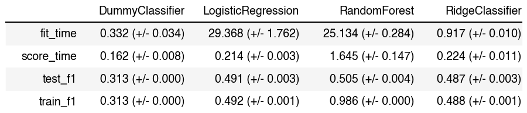

Table 1. Model Results based on f1 score

### Hyperparameter tuning

For LogisticRegression, hyperparameters `C` and `class_weight` were optimized via RandomizedSearchCV to maximize f-1. The best model performed using `C = 100` and `class_weight = None`.

- Note: due to the time complexity of the model, the hyperparameter optimization took a significant amount of time to complete. RandomizedSearchCV returns the best parameters it can find in a set amount of time, so it’s possible that these are not the best parameters overall, but the best parameter that could be fit in the given time frame.

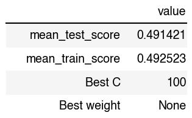

Table 2. Model Results

## Results and Discussion

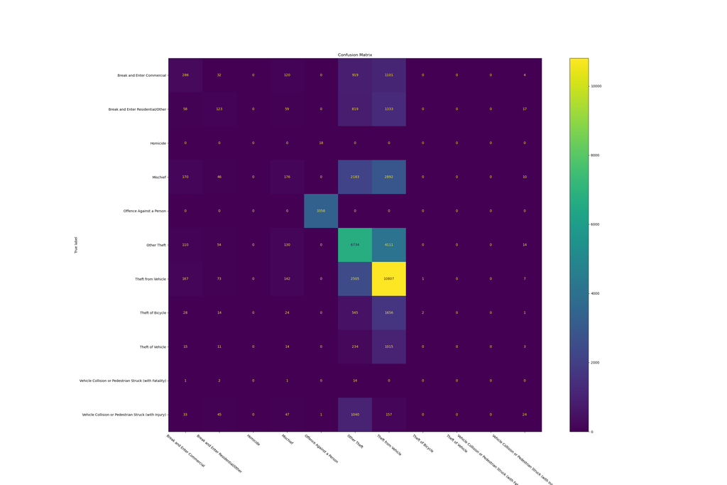

Figure 5. Confusion Matrix of LogisticRegressor performance on test data

Furthermore, based on the classification report of breaking down individual precision, recall, f1-scores, and support score, there is further confirmation of the model’s poor performance, where some of the classes had zero success in prediction ( `Homicide`, `Theft of Vehicle`, `Vehicle Collision (with Fatality)`).

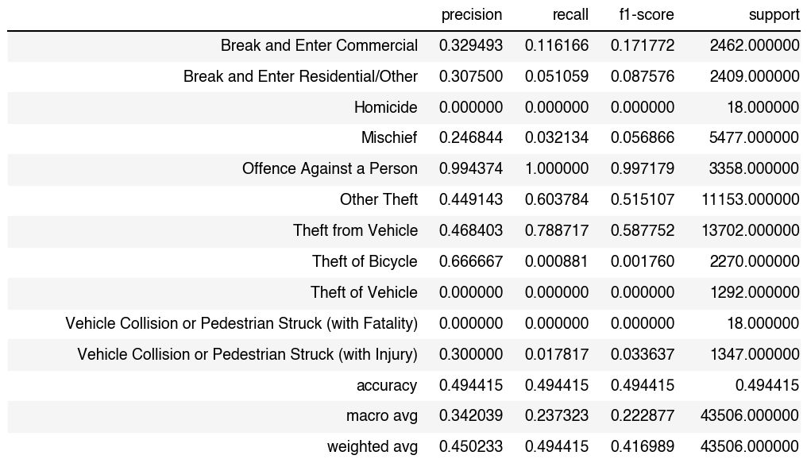

Table 3. Classification Report of Targets

Overall, the model created performs poorly on the test and training data. This model would not generalize well on unseen data, and thus could be improved upon in future updates.

Ultimately, the most likely explanation for the model’s poor performance is the quality of input data used. Even with data re-balancing to handle the 0 AM imbalance and hyperparameter optimization, the model did not improve much. To further improve the model in the future, feature engineering could be used to optimize/create new features in the dataset to boost model predictions. Additionally, adding relevant data from an outside source (ie. Vancouver weather, Vancouver housing prices, etc.) could be useful to create more meaningful features for the model to train on. Finally, testing different model than LogisticRegressor, RandomForestClassifier, and RidgeClassifier could also result in a better performing model.

## References

de Jonge, Edwin. 2018. *Docopt: Command-Line Interface Specification Language*. https://github.com/docopt/docopt.

Harris, Charles R., K. Jarrod Millman, Stéfan J van der Walt, Ralf Gommers, Pauli Virtanen, David Cournapeau, Eric Wieser, et al. 2020. “Array Programming with NumPy.” *Nature* 585: 357–62. https://doi.org/10.1038/s41586-020-2649-2.

McKinney, Wes et al. 2010. “Data Structures for Statistical Computing in Python.” In *Proceedings of the 9th Python in Science Conference*, 445:51–56. Austin, TX.

Pedregosa, Fabian, Gaël Varoquaux, Alexandre Gramfort, Vincent Michel, Bertrand Thirion, Olivier Grisel, Mathieu Blondel, et al. 2011. “Scikit-Learn: Machine Learning in Python.” *Journal of Machine Learning Research* 12 (Oct): 2825–30.

Petrou, Ted. 2018. *Dexplot: Dexplot Is a Powerful and Intuitive Python Data Visualization Library Using Matplotlib for Both Long and Wide Data*. https://www.dexplo.org/dexplot.

Tharwat, Alaa. 2020. “Classification Assessment Methods.” *Applied Computing and Informatics*.

The Vancouver Police Department. 2021. *Vancouver Department Open Data*. https://geodash.vpd.ca/opendata/.

Van Rossum, Guido, and Fred L Drake Jr. 1995. *Python Tutorial*. Centrum voor Wiskunde en Informatica Amsterdam, The Netherlands.

VanderPlas, Jacob, Brian Granger, Jeffrey Heer, Dominik Moritz, Kanit Wongsuphasawat, Arvind Satyanarayan, Eitan Lees, Ilia Timofeev, Ben Welsh, and Scott Sievert. 2018. “Altair: Interactive Statistical Visualizations for Python.” *Journal of Open Source Software* 3 (32): 1057.